# Class 11 - Simple Exponential Smoothing

Fadel Megahed

# 1 Loading the Packages

In the code chunk below, we are loading some of the packages that we will be using in today’s class

```r
if(require(pacman) == FALSE) install.packages("pacman")
pacman::p_load(tidyverse, tidyquant, fpp2, magrittr, scales)
```

# 2 The Sales Example from P.72 in Your Reference Book

```r
df = data.frame(time = 1:12,
                sales = c(5, 6, 7, 8, 7, 6, 5, 6, 7, 8, 7, 6) )
```

# 3 Training and Validation Samples

## 3.1 The Basic Idea

**Often you determine your smoothing parameter based on a training or baseline sample of observations, not the entire series. Then you apply the model using the smoothing parameter to the new observations and evaluate the fit on the out-of-sample observations.**

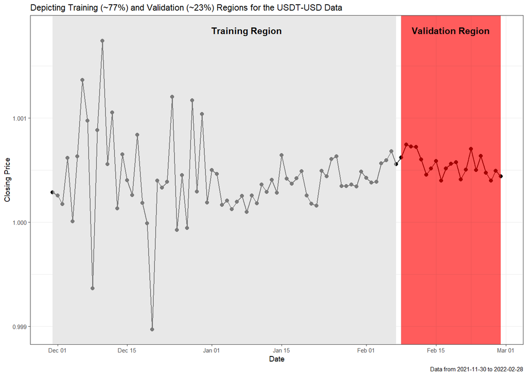

```r
usdt = tidyquant::tq_get('USDT-USD', from = Sys.Date()-90, to = Sys.Date()) %>%
  dplyr::select(date, adjusted)

usdt %>% ggplot(aes(x = date, y = adjusted)) +
  geom_line() + geom_point() +
  theme_bw(base_size = 7) +
  scale_x_date(breaks = pretty_breaks(10)) + # beautifying the x-axis
  geom_rect(xmin = usdt$date[1], xmax = usdt$date[70],
            ymin = min(usdt$adjusted) - 0.0005,
            ymax = max(usdt$adjusted) + 0.0005, alpha = 0.01, fill = 'gray') +
  geom_rect(xmin = usdt$date[71], xmax = usdt$date[91],
            ymin = min(usdt$adjusted) - 0.0005,
            ymax = max(usdt$adjusted) + 0.0005, alpha = 0.01, fill = 'red') +
  annotate("text", x = usdt$date[40], y = max(usdt$adjusted) + 0.0001,
             color = 'black', label = "Training Region", size = 3, fontface = 'bold') +
  annotate("text", x = usdt$date[81], y = max(usdt$adjusted) + 0.0001,
             color = 'black', label = "Validation Region", size = 3, fontface = 'bold') +
  labs(x = 'Date', y = 'Closing Price',
  caption = paste('Data from', min(usdt$date), 'to', max(usdt$date)),
       title = 'Depicting Training (~77%) and Validation (~23%) Regions for the USDT-USD Data')
```

## 3.2 The Five-Step Process

1. Determine the size of the training, or baseline sample.
   1. Training sample size is usually 70-80% of the total available data.
   2. Training sample should maintain time order. With time series, the training sample usually consists of observations at the beginning of the sample, while validation sample consists of observations at the end of the available data.
2. Select the smoothing parameter based on the observations in the training sample only.
3. Evaluate the “in-sample” performance of the forecast using RMSE and graphs using the training sample.
4. Apply the model chosen in #2 to the validation sample.
5. Evaluate the “out-of-sample” performance of the forecast using RMSE and graphs.

### 3.2.1 Optimizing the Smoothing Parameter: WFJ Sales Series

To illustrate the aforementioned concepts, let us examine the data for the [WFJ Sales Example](https://github.com/fmegahed/businessForecasting/blob/master/assignments/WFJ_sales.xlsx?raw=true) (i.e., Example 3.2 in our reference book). Per the reference book example, we will use the first the **26 observations** as the training sample.

```r
pacman::p_load(readxl)
download.file(url = 'https://github.com/fmegahed/businessForecasting/blob/master/assignments/WFJ_sales.xlsx?raw=true', destfile = 'WFJ_sales.xlsx', mode = 'wb')
WFJ = read_excel("WFJ_sales.xlsx") %>% select(c(1,2))
```